# Progress Memo 2

Final Project  
Data Science 1 with R (STAT 301-1)

Author

Karthik Sathish

Published

November 29, 2023

**Github Repo Link**

[My Github Repo Link](https://github.com/stat301-1-2023-fall/final-project-1-kvsathish)

### Packages and Datasets Loaded

## Approaching the Central Question

The dataset for analysis is named `Michael Jordan, Kobe Bryant and Lebron James stats`[^1]. Some of the raw statistical data is also from Basketball Reference[^2].

My central question revolves around which of the three basketball players in the dataset is the greatest basketball player of all time. To approach this question, I’ve decided to evaluate it by who would have won the MVP the most times between the three individuals. I’m restricting the timeframe to the first fifteen seasons of each player’s respective career. This was decided to limit out the longevity arguments for players that have had longer careers than others. Now, I understand that the Most Valuable Player in the NBA is often based on a player’s merit as well as team success. To assign the MVP to one of these three players in their first fifteen seasons, I have come up with my own metric score for evaluation.

The MVP will be a much more statistically based award. This is because I will be using a variety of stats reflecting a player’s true impact over every single minute played during a season. To measure offensive output, I am including points, assists, and rebounds. For defensive output, I am additionally using steals and blocks. The specific `Score` for each player in a given season will be calculated by:

Score = (Points + Assists + Rebounds + Steals + Blocks) / Minutes Played

Once this score is calculated for each game played in a given season for a player, the average of all the scores in a season will be computed as a final reflection to compare. The greatest final mean score, each season, will justify who should’ve won the MVP. Then, I plan to add up MVPs for each player and deduce which player is the most valuable the most number of seasons. I believe that this analysis justifies who was the greatest NBA player from the first fifteen seasons of their respective careers.

## Data Cleaning

In terms of cleaning the data, the `NA` values present in the dataset never factored into the specific variables I plan to manipulate for analysis. Since these specific variables didn’t have `NA` values, I didn’t eliminate the observations that might have had an `NA` value for a separate variable. Also, I made sure to convert the `MP` variable, representing minutes played, from `difftime` type to a numeric type so my calculated score could be performed with the corresponding data.

## Progress for Project

In the following formatted tables, I show the first five scores from the first five games played by each of the three players in their first season. Also, I returned the average score over the course of the first season for Kobe Bryant, Lebron James, and Michael Jordan. Although these tables only reflect the first season of each player’s career, I plan to repeat this process for calculating mean scores for the next fourteen seasons in my final project.

##### Kobe Bryant’s First Season

| Player | Date | Score |
| --- | --- | --- |
| Kobe Bryant | 1996-11-03 | 0.9259259 |
| Kobe Bryant | 1996-11-05 | 0.9259259 |
| Kobe Bryant | 1996-11-06 | 1.9841270 |
| Kobe Bryant | 1996-11-08 | 2.2875817 |
| Kobe Bryant | 1996-11-10 | 2.0833333 |

| Mean_Score |
| --- |
| 1.958373 |

##### Lebron James’ First Season

| Player | Date | Score |
| --- | --- | --- |
| Lebron James | 2003-10-29 | 2.910053 |
| Lebron James | 2003-10-30 | 2.845528 |
| Lebron James | 2003-11-01 | 1.424501 |
| Lebron James | 2003-11-05 | 2.032520 |
| Lebron James | 2003-11-07 | 1.957071 |

| Mean_Score |
| --- |
| 2.418668 |

##### Michael Jordan’s First Season

| Player | Date | Score |
| --- | --- | --- |
| Michael Jordan | 1984-10-26 | 2.430556 |
| Michael Jordan | 1984-10-27 | 2.777778 |
| Michael Jordan | 1984-10-29 | 4.411765 |
| Michael Jordan | 1984-10-30 | 2.932099 |
| Michael Jordan | 1984-11-01 | 2.441077 |

| Mean_Score |
| --- |
| 3.164302 |

According to the mean scores found for each of the three players across the course of their respective first season, Michael Jordan would have won the first MVP between the players. This is because he earned the greatest mean score of approximately 3.16, compared to 2.41 for Lebron James and 1.96 for Kobe Bryant.

### Univariate Analyses

In the following univariate analyses, I constructed boxplots that represent the distribution of scores in each of the player’s first season. These graphics help visualize the centers of the respective scores as well as how the scores are spread in the first season for each player. These boxplots are displayed because they reveal where the middle 50% of scores lie (IQR) as well as if there are outliers that may be skewing the data one way or another.

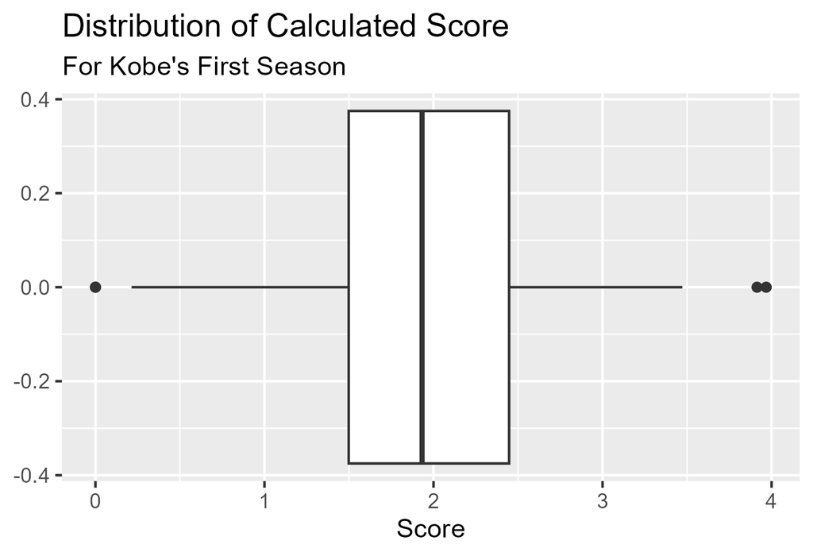

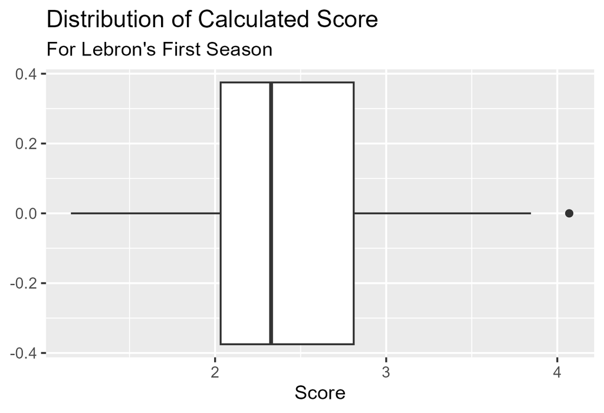

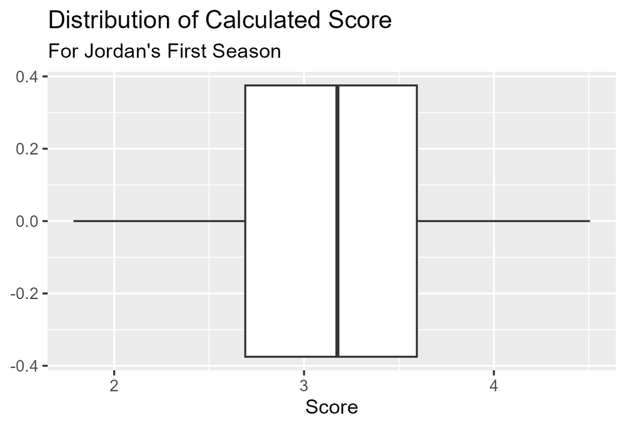

### Bivariate Analyses

In the following bivariate analyses, I constructed scatterplots that represent the scores by the date during each of the player’s first season. These graphics help how scores might have changed over the course of the season for each player. These scatterplots are displayed because they reveal if any type of relationship exists between different times during the season and a player’s score. According to the linear line of best fit, it can be concluded that players generally showed improved scores over the course of the season. This is because the three linear lines of best fit are all weakly positive.

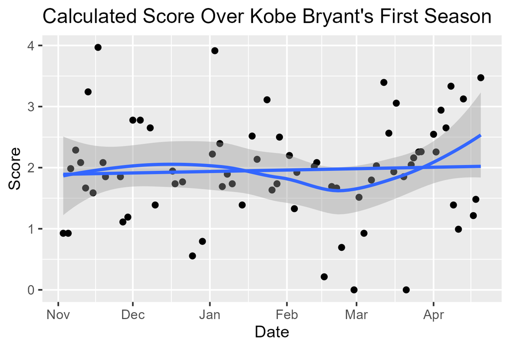

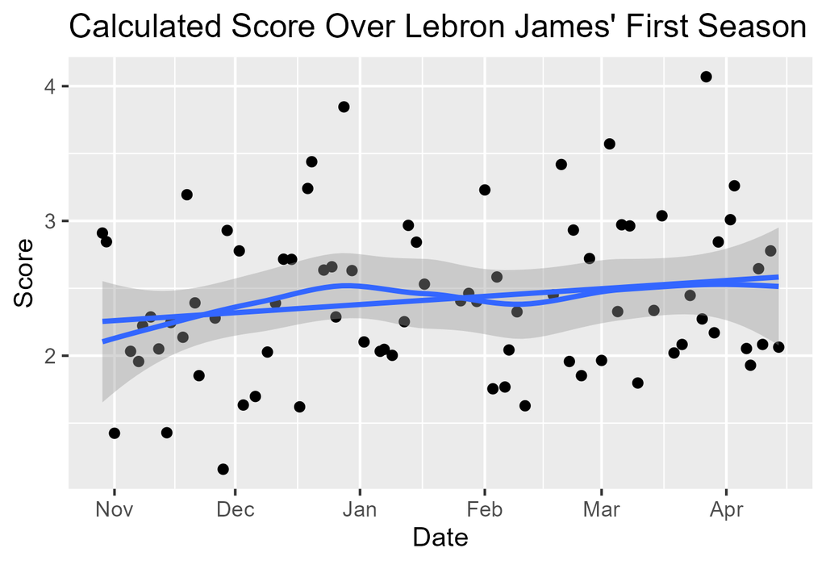

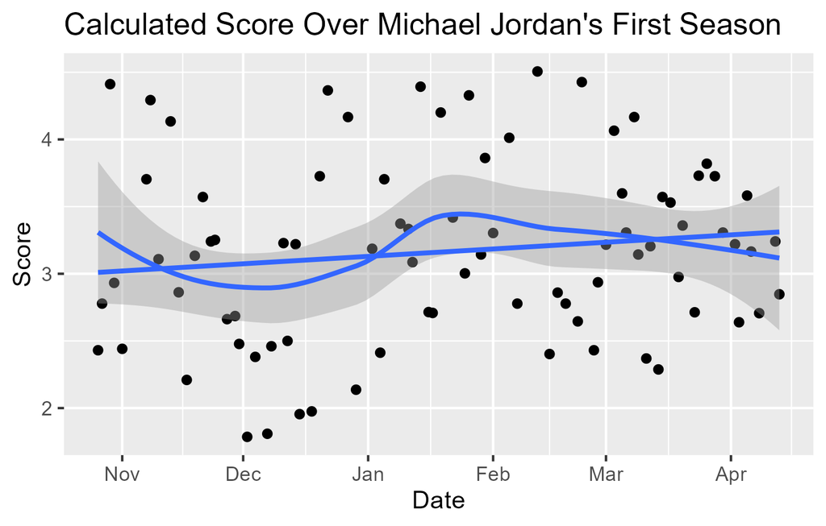

## Reflection and Next Steps

So far, I am proud of the data analysis performed, but there is definitely room for improvement. One area that is tough to get around is adjusting the scores to their respective time period accordingly. During various times in NBA history, the style of the game shifted in terms of strategy, defensive intensity, spacing, and scoring. To account for this in future analysis, I plan to adjust Point scored by each player to account for point inflation/deflation during different years. This could be done with a comparison between points scored and total points averaged by the respective team.

Another variable that I plan to involve in future analyses is `TOV` or turnovers. In my calculation, I will subtract turnovers from assists to receive more accurate scores about player performance statistically. The inclusion of turnovers adds a metric that accounts for the negative impact a player may have in each game during a season.

Finally, I am not quite sure how to evaluate scores from the postseason. This is a difficult area to compare because the three players made it to the postseason at different points in their career. Also, some made it further than others which could distort scores. I plan to exclude postseason success and scores from my analysis, so I can evaluate the raw statistical performance of each player during the first fifteen seasons of their respective careers.

Before the extra credit deadline (11/29), I plan to account for the necessary adjustments above and complete my analysis for the next fourteen seasons of each player’s career.

## Footnotes

[^1]: Found on https://www.kaggle.com/datasets/xvivancos/michael-jordan-kobe-bryant-and-lebron-james-stats/data?select=per_game_stats.csv
[^2]: Found on https://www.basketball-reference.com/